# Accounting, Analysis and Governance in Complex Deals

Arndt Weinrich

weinrich@rsm.nl

Rotterdam School of Management

# Valuation & Pricing

> **BMME303**

> Accounting, Analysis and Governance in Complex Deals

## Value and Price

### Setting the Stage

#### Value and Price Refer to Different Things

[figure not shown]

| Price | Value |
| --- | --- |
| Observable/Unique | Can be Ambiguous |
| No Model | Model/Theory Needed |

*We will ignore this distinction and use the terms interchangeably*

## Lecture Overview

### Structure and Learning Objectives

#### Key Topics

- Role of boards in acquisitions: fairness opinions
- Market-based valuation methods
  - Theory
  - Application

#### Learning Objectives

- Understand the role of boards in M&A transactions
- Evaluate the importance of fairness opinions
- Analyze different valuation methods
- Apply market-based valuation techniques

# The Role of Boards (Again)

> **BMME303**

> Valuation & Pricing

## The role of boards?

### Valuation & Pricing

**Fiduciary Responsibilities**

- Duty of care: Make **informed decisions** with appropriate diligence
- Duty of loyalty: Act in shareholders’ best interests, not self-interest (stewardship)

$\Rightarrow$ *How do these responsibilities influence the (target’s) board with regard to valuation?*

## Fiduciary Responsibilities

### The role of boards?

- Board must determine whether a transaction is financially fair to shareholders!
- **Fairness opinions** help demonstrate fulfillment of these duties
  - FOs particularly important in transactions with potential **conflicts**
  - FO creates **documentation** of board’s decision-making process

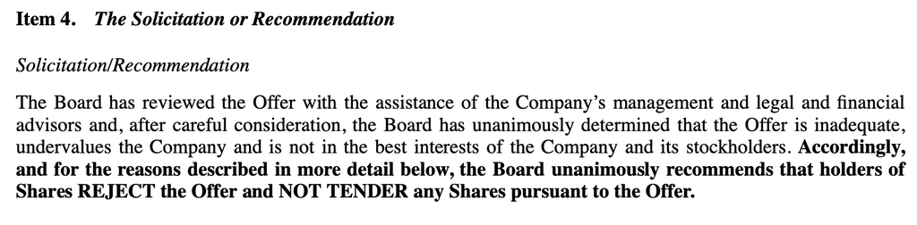

[Fairness Opinion - Schedule 14D-9](https://www.sec.gov/Archives/edgar/data/1124941/000121390025010736/ea0229555-sc14d9_beacon.htm) by Beacon in response to QXO’s acquisition offer (see this [FT Summary](https://ask.ft.com/answer/8ce096c4-d948-4cc7-ac2e-03f6bf430176) for details on the case)

## Fairness Opinions

### Fiduciary Responsibilities

#### What is a Fairness Opinion?

- A professional evaluation *provided by investment banks or financial advisors*
- FO assesses whether transaction terms are financially fair to shareholders
- Not technically required by law but effectively mandated by case law and practice (USA)
- The actual value of fairness opinions is ambiguous:
  - Subjective choice of valuation methods
  - Can help in negotiations
  - Can provide information about mispricing and potential synergies

## Fairness Opinions

### Fiduciary Responsibilities

#### Historical Context

- Litigation: 1985 *Smith v. Van Gorkom* ([Trans Union case](https://en.wikipedia.org/wiki/Smith_v._Van_Gorkom))
- Delaware Supreme Court held directors personally liable for approving a merger without adequate information
- Created a strong incentive for boards to obtain independent fairness opinions
  - Established as a key protection against director liability
  - Now a standard component of significant corporate transactions

## Who is Involved?

### Fairness Opinions

#### Investment Banks and Financial Advisors

- Primary preparers of fairness opinions
- Apply valuation expertise, market knowledge, and analytical capabilities
- Typically receive significant fees for their services

#### Corporate Boards

- Demonstrate fulfillment of fiduciary duties
- Manage conflicts of interest in transactions
- Hedge against personal liability although business judgment rule provides some protection

# Fairness Opinions: Empirical Evidence

## Fairness Opinions

### Litigation Risk and Strategic M&A Valuations (Imperatore et al. 2024)

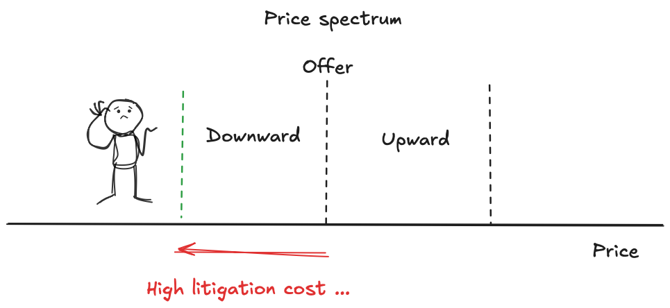

*$\rightarrow$ litigation risk for the board (angry shareholders!) increases when offer/price approaches the lower bound of the price spectrum (laid out in the fairness opinion)*

## Strategic Fairness Opinions?

### Litigation Risk and Strategic M&A Valuations (Imperatore et al. 2024)

#### Research question

Does strategic target valuation in fairness opinions mitigate litigation risk for target boards?

#### Identification Strategy

- Measure strategic target valuation
  - *“We focus on the two most common valuation methods used in fairness opinions: Peer Comparables Analyses (PPP) and Discounted Cash Flow (DCF) analyses.”*
- Exogenous variation in litigation risk

## Strategic Fairness Opinions?

### Litigation Risk and Strategic M&A Valuations (Imperatore et al. 2024)

[figure not shown]

$\Rightarrow$ *DCF valuations in FOs tend to fall below the actual purchase price more frequently than they fall above it*

## Identification Strategy

### Litigation Risk and Strategic M&A Valuations (Imperatore et al. 2024)

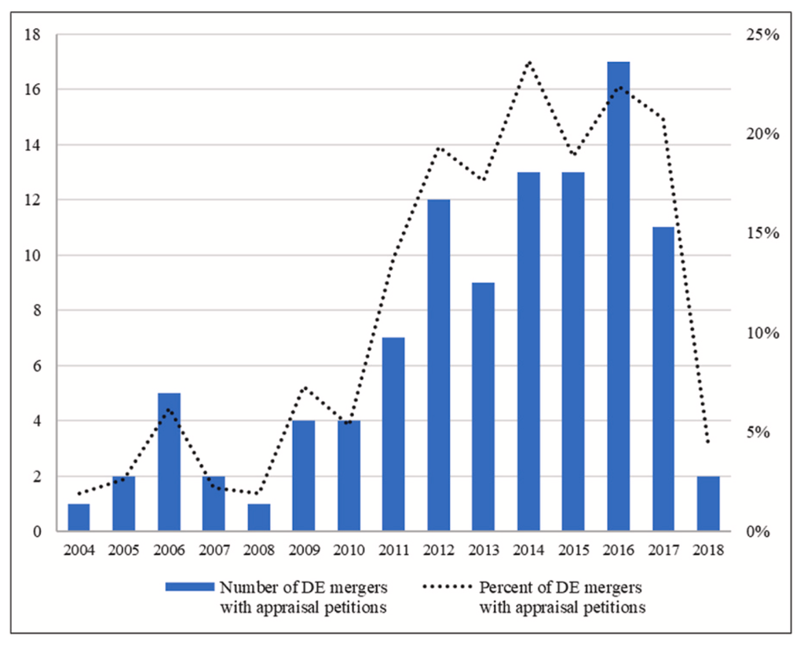

*Exploit variation in litigation risk that followed a landmark Delaware case in 2007 to answer RQ*

## FOs to Mitigate Litigation Risk?

### Litigation Risk and Strategic M&A Valuations (Imperatore et al. 2024)

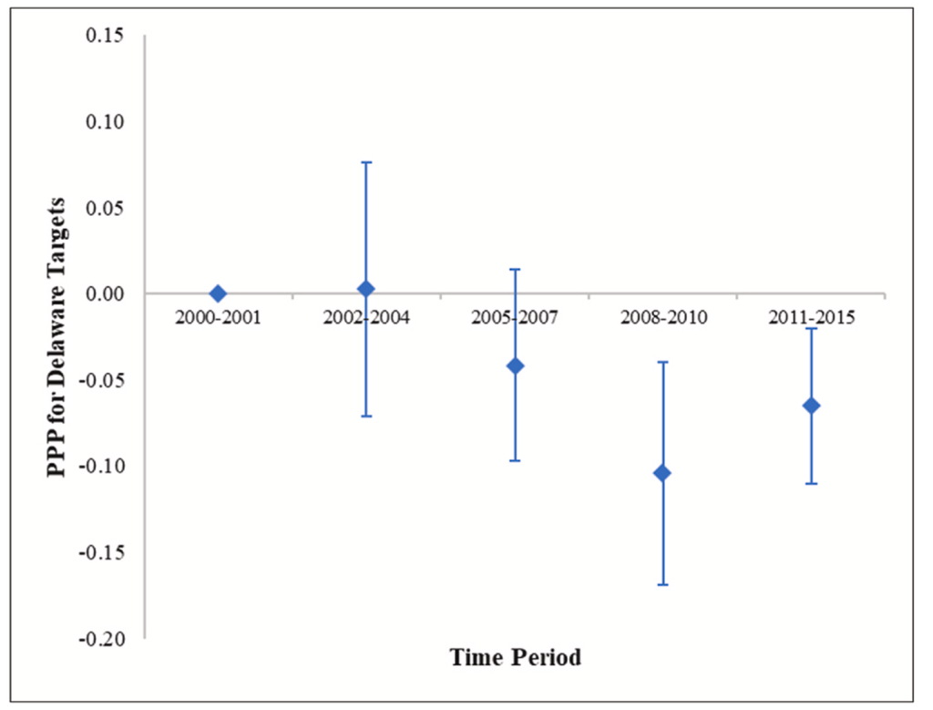

**Main Findings**

- FO valuations decline for DE targets
- Stronger decline for targets with higher agency risks (MBO, going dark)
- Consequences of downward bias in FO valuations:
- Value of combined firm $\uparrow$
- Acquisition premium $\downarrow$

# Fairness Opinions: Case Study

## Beacon vs. QXO

### Fairness Opinions in Practice

Case

> In the takeover (attempt) of Beacon by QXO, fairness opinions played a crucial role, albeit in an unusual manner. Instead of traditional (?) fairness opinions supporting a deal, Beacon’s board sought “inadequacy opinions” or “unfairness opinions” to justify rejecting QXO’s tender offer. Lazard and JPMorgan, two prominent investment banks, were engaged to provide these opinions. On February 5, 2025, Lazard presented its analysis orally, followed by JPMorgan offering its separate opinion. Both banks concluded that QXO’s bid was too low.

## Beacon vs. QXO

### Fairness Opinions in Practice

#### Strategic Application

- Instead of support, used to reject it
- Detailed financial analyses were not published
- Advisors orally presented their analyses

#### Methodology

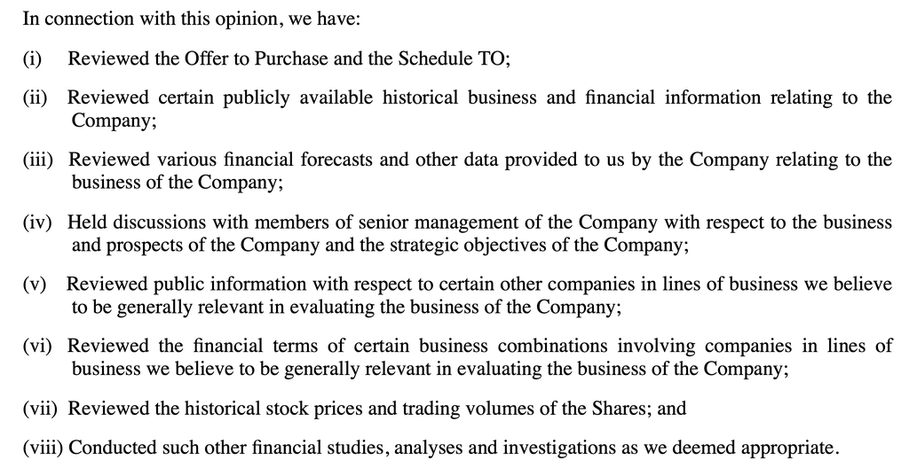

$\Rightarrow$ Both advisors concluded the bid was “financially inadequate”

## Beacon vs. QXO

### Fairness Opinions in Practice

#### Compensation Arrangements

**Lazard**

- $4,000,000 for initial inadequacy opinion
- $1.5m for each additional opinion ($7m cap)

**JPMorgan**

- $4,000,000 for providing the opinion
- $50 million+ success fee if Beacon ultimately acquired

#### Inherent Conflicts?

- **Misaligned incentives** between advisors and shareholders
  - Lazard is incentivized to provide exactly three opinions (to reach cap)
  - JPMorgan’s dual role: help reject current bid but profit from eventual acquisition
- Role of **disclosure**?

## Beacon vs. QXO

### Fairness Opinions in Practice

#### Limited Disclosure Approach

- Beacon disclosed the existence of inadequacy opinions but minimal details
- No publication of:
  - Peer firms
  - Valuation assumptions
  - “Adequate” price ranges
- Less transparency than in typical fairness opinions supporting a deal

#### Potential Strategic Valuation Choices

- Selection of peer firms with
  - optimistically high valuations?
  - potentially influenced by advisor incentive structures
- Limited public disclosure prevents scrutiny of these choices

## Board, Fairness Opinions, and Valuation

### Key Takeaways

- **Fairness Opinions**: Essential for boards to fulfill fiduciary duties (care and loyalty) and manage litigation risk
- **Independent Assessments**: Evaluate transaction fairness for shareholders
- **Key Players**: Investment banks and financial advisors provide expertise
- **Strategic Use**: Increasingly used to reject or support deals (e.g., Beacon vs. QXO)
- **Challenges**:
  - Potential conflicts of interest (e.g., fee structures)
  - Additional information vs. protection from litigation

## Thank You!

[figure not shown]

# Appendix

## References

Imperatore, Claudia, Gabriel Pündrich, Rodrigo S Verdi, and Benjamin P Yost. 2024. “Litigation risk and strategic M&A valuations.” *Journal of Accounting and Economics* 78 (1): 101671.

## Copyright

### © Erasmus University Rotterdam, all rights reserved. No text and data mining.

**English** This study material is protected by copyright under Dutch copyright laws. It is provided solely for your personal use and study. You are allowed to create a copy for your personal use. You are not allowed to make this study material or parts thereof available to others or reproduce it without prior written permission of the Erasmus University Rotterdam.

**Nederlands** Dit onderwijsmateriaal is een auteursrechtelijk beschermd werk in de zin van de Auteurswet. Het wordt in het kader van uw studie aan u ter beschikking gesteld en is uitsluitend bedoeld voor uw eigen persoonliike gebruik. U mag daarvoor een persoonliike kopie maken. Het verveelvoudigen en openbaar maken (waaronder begrepen het aan derden ter beschikking stellen en/of verspreiden) van dit onderwiismateriaal of een gedeelte daarvan is niet toegestaan zonder voorafgaande schrifteliike toestemming van de Erasmus Universiteit Rotterdam.

Titlepage photo by [Dennis Möller](https://unsplash.com/@ennismo?utm_source=unsplash&utm_medium=referral&utm_content=creditCopyText) on [Unsplash](https://unsplash.com/photos/city-skyline-under-blue-sky-during-night-time-946XeVrYO2E?utm_source=unsplash&utm_medium=referral&utm_content=creditCopyText)